# Data Pre-processing

Normalization and Standardization using `caret`

The quality of the data and the amount of useful information that it contains are *key factors* that determine how well a data mining algorithm can extract knowledge from data and how machine learning algorithms can learn.

It is absolutely critical that we make sure to **examine** and **preprocess** a dataset before.

## Data pre-processing with the `caret` package in R

```r
# load the caret package
library(caret)
```

The `caret` package (short for **C**lassification **A**nd **RE**gression **T**raining) is a set of functions that attempt to streamline the process for creating predictive models. Full documentation can be found [here](http://topepo.github.io/caret/index.html)

The `caret` package in R provides a number of useful *data transforms*. (it assumes that all of the data are numeric)

The model of the transform is prepared using the `preProcess()` function and applied to a dataset using the `predict()` function.

Consider the `iris` dataset. The famous (Fisher’s or Anderson’s) `iris` data set gives the measurements in centimeters of the variables sepal length and width and petal length and width, respectively, for 50 flowers from each of 3 species of iris. The `species` are Iris setosa, versicolor, and virginica.

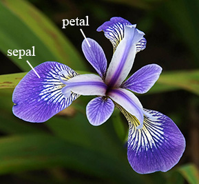

Sepal and Petal

Check the first entries of the `iris` dataset:

```r
head(iris)
```

|  | Sepal.Length | Sepal.Width | Petal.Length | Petal.Width | Species |
| --- | --- | --- | --- | --- | --- |
| 1 | 5.1 | 3.5 | 1.4 | 0.2 | setosa |
| 2 | 4.9 | 3.0 | 1.4 | 0.2 | setosa |
| 3 | 4.7 | 3.2 | 1.3 | 0.2 | setosa |
| 4 | 4.6 | 3.1 | 1.5 | 0.2 | setosa |
| 5 | 5.0 | 3.6 | 1.4 | 0.2 | setosa |
| 6 | 5.4 | 3.9 | 1.7 | 0.4 | setosa |

For the purpose of illustration, let us create a copy of the `iris` dataset ignoring the column `Species` (since it is not numeric), that is, we ignore the 5th column in the original dataset:

```r
# load the tidyverse package for data transformation
library(tidyverse)
```

```r
# we use the select() function - part of the tidyverse -
my_iris <- iris %>%
  select(-Species)
```

Summary statistics are shown below:

```r
# summarize data
summary(my_iris)
```

```
  Sepal.Length    Sepal.Width     Petal.Length    Petal.Width
 Min.   :4.300   Min.   :2.000   Min.   :1.000   Min.   :0.100
 1st Qu.:5.100   1st Qu.:2.800   1st Qu.:1.600   1st Qu.:0.300
 Median :5.800   Median :3.000   Median :4.350   Median :1.300
 Mean   :5.843   Mean   :3.057   Mean   :3.758   Mean   :1.199
 3rd Qu.:6.400   3rd Qu.:3.300   3rd Qu.:5.100   3rd Qu.:1.800
 Max.   :7.900   Max.   :4.400   Max.   :6.900   Max.   :2.500
```

### Scaling

The `scale` transform calculates the *standard deviation* for an attribute and divides each value by that standard deviation.

```r
# calculate the pre-process parameters from the dataset
preprocessParams_scale <- preProcess(my_iris, method=c("scale"))
```

We now use the `predict()` function to see the new transformed data:

```r
# transform the dataset using the parameters
transformed_scale <- predict(preprocessParams_scale, my_iris)
# summarize the transformed dataset
summary(transformed_scale)
```

```
  Sepal.Length    Sepal.Width      Petal.Length     Petal.Width
 Min.   :5.193   Min.   : 4.589   Min.   :0.5665   Min.   :0.1312
 1st Qu.:6.159   1st Qu.: 6.424   1st Qu.:0.9064   1st Qu.:0.3936
 Median :7.004   Median : 6.883   Median :2.4642   Median :1.7055
 Mean   :7.057   Mean   : 7.014   Mean   :2.1288   Mean   :1.5734
 3rd Qu.:7.729   3rd Qu.: 7.571   3rd Qu.:2.8890   3rd Qu.:2.3615
 Max.   :9.540   Max.   :10.095   Max.   :3.9087   Max.   :3.2798
```

## Centering

The `center` transform calculates the *mean* for an attribute and subtracts it from each value.

```r
# calculate the pre-process parameters from the dataset
preprocessParams_center <- preProcess(my_iris, method=c("center"))
# transform the dataset using the parameters
transformed_center <- predict(preprocessParams_center, my_iris)
# summarize the transformed dataset
summary(transformed_center)
```

```
  Sepal.Length       Sepal.Width        Petal.Length     Petal.Width
 Min.   :-1.54333   Min.   :-1.05733   Min.   :-2.758   Min.   :-1.0993
 1st Qu.:-0.74333   1st Qu.:-0.25733   1st Qu.:-2.158   1st Qu.:-0.8993
 Median :-0.04333   Median :-0.05733   Median : 0.592   Median : 0.1007
 Mean   : 0.00000   Mean   : 0.00000   Mean   : 0.000   Mean   : 0.0000
 3rd Qu.: 0.55667   3rd Qu.: 0.24267   3rd Qu.: 1.342   3rd Qu.: 0.6007
 Max.   : 2.05667   Max.   : 1.34267   Max.   : 3.142   Max.   : 1.3007
```

## Standardizing

Combining the `scale` and `center` transforms will *standardize* your data. Attributes will have a mean value of 0 and a standard deviation of 1.

```r
# calculate the pre-process parameters from the dataset
preprocessParams_std <- preProcess(my_iris, method = c("center", "scale"))

# transform the dataset using the parameters
transformed_std <- predict(preprocessParams_std, my_iris)

# summarize the transformed dataset
summary(transformed_std)
```

```
  Sepal.Length       Sepal.Width       Petal.Length      Petal.Width
 Min.   :-1.86378   Min.   :-2.4258   Min.   :-1.5623   Min.   :-1.4422
 1st Qu.:-0.89767   1st Qu.:-0.5904   1st Qu.:-1.2225   1st Qu.:-1.1799
 Median :-0.05233   Median :-0.1315   Median : 0.3354   Median : 0.1321
 Mean   : 0.00000   Mean   : 0.0000   Mean   : 0.0000   Mean   : 0.0000
 3rd Qu.: 0.67225   3rd Qu.: 0.5567   3rd Qu.: 0.7602   3rd Qu.: 0.7880
 Max.   : 2.48370   Max.   : 3.0805   Max.   : 1.7799   Max.   : 1.7064
```

```r
sd(transformed_std$Petal.Length)
```

```
[1] 1
```

## Normalizing

Data values can be scaled into the range of $[0, 1]$ which is called *normalization*.

```r
# calculate the pre-process parameters from the dataset
preprocessParams_norm <- preProcess(my_iris, method = c("range"))

# transform the dataset using the parameters
transformed_norm <- predict(preprocessParams_norm, my_iris)

# summarize the transformed dataset
summary(transformed_norm)
```

```
  Sepal.Length     Sepal.Width      Petal.Length     Petal.Width
 Min.   :0.0000   Min.   :0.0000   Min.   :0.0000   Min.   :0.00000
 1st Qu.:0.2222   1st Qu.:0.3333   1st Qu.:0.1017   1st Qu.:0.08333
 Median :0.4167   Median :0.4167   Median :0.5678   Median :0.50000
 Mean   :0.4287   Mean   :0.4406   Mean   :0.4675   Mean   :0.45806
 3rd Qu.:0.5833   3rd Qu.:0.5417   3rd Qu.:0.6949   3rd Qu.:0.70833
 Max.   :1.0000   Max.   :1.0000   Max.   :1.0000   Max.   :1.00000
```